## Máster en Data Science - Series Temporales

# BSTS

Autor: Ramón Morillo Barrera

## Dataset: Madrid.csv

Los modelos Bayesian Structural Time Series (BSTS) representan un enfoque avanzado y flexible para el análisis de series temporales que combina elementos del modelado estructural clásico con inferencia bayesiana. Esta metodología, desarrollada inicialmente por investigadores de Google, permite descomponer una serie temporal en sus componentes fundamentales (tendencia, estacionalidad y ciclos), mientras incorpora la incertidumbre en la estimación de parámetros a través de distribuciones de probabilidad. Los BSTS se destacan por su capacidad para manejar datos faltantes, incorporar variables explicativas, y realizar predicciones robustas con intervalos de credibilidad, lo que los hace particularmente valiosos en aplicaciones empresariales como la previsión de ventas, el análisis de marketing y la evaluación del impacto de intervenciones comerciales.

```python
# librerías
from bsts import BSTS
import numpyro
import matplotlib.pyplot as plt
import pandas as pd
import numpy as np
from causalimpact import CausalImpact
from sklearn.metrics import mean_squared_error, mean_absolute_percentage_error

import warnings
warnings.filterwarnings("ignore")
```

[output not shown]

### Importar datos

```python
df_autobus_month = pd.read_csv('../data/processed/Madrid_autobus_month.csv', index_col='Periodo')
df_metro_month = pd.read_csv('../data/processed/Madrid_metro_month.csv', index_col='Periodo')
df_combined_month = pd.read_csv('../data/processed/Madrid_combined_month.csv', index_col='Periodo')

df_autobus_trim = pd.read_csv('../data/processed/Madrid_autobus_trim.csv', index_col='Periodo')
df_metro_trim = pd.read_csv('../data/processed/Madrid_metro_trim.csv', index_col='Periodo')
df_combined_trim = pd.read_csv('../data/processed/Madrid_combined_trim.csv', index_col='Periodo')
```

```python
df_autobus_month = df_autobus_month[ 'Total']
df_autobus_trim = df_autobus_trim['Total']
df_combined_month = df_combined_month[ 'Total']
df_combined_trim = df_combined_trim['Total']
df_metro_month = df_metro_month['Total']
df_metro_trim = df_metro_trim['Total']
```

```python
df_autobus_month.index = pd.to_datetime(df_autobus_month.index)
df_autobus_trim.index = pd.to_datetime(df_autobus_trim.index)
df_combined_month.index = pd.to_datetime(df_combined_month.index)
df_combined_trim.index = pd.to_datetime(df_combined_trim.index)
df_metro_month.index = pd.to_datetime(df_metro_month.index)
df_metro_trim.index = pd.to_datetime(df_metro_trim.index)

df_autobus_month = df_autobus_month.resample("M").last()
df_autobus_trim = df_autobus_trim.resample("QE").last()
df_combined_month = df_combined_month.resample("M").last()
df_combined_trim = df_combined_trim.resample("QE").last()
df_metro_month = df_metro_month.resample("M").last()
df_metro_trim = df_metro_trim.resample("QE").last()
```

## Modelo BSTS

Los modelos de predicción de series temporales BSTS (Bayesian Structural Time Series) son una metodología estadística que combina técnicas de series temporales clásicas con un enfoque bayesiano para modelar y predecir datos secuenciales. Estos modelos se basan en la descomposición de las series temporales en componentes estructurales, como tendencia, estacionalidad y ciclos, permitiendo así una interpretación más clara y flexible. Al ser bayesianos, los modelos BSTS proporcionan una estimación probabilística que permite incorporar la incertidumbre de las predicciones, lo que los hace útiles en situaciones donde los datos son ruidosos o cuando se requiere un enfoque robusto para capturar patrones complejos.

### Series mensuales

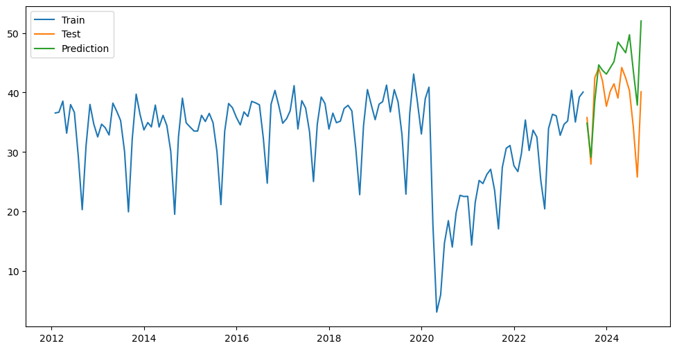

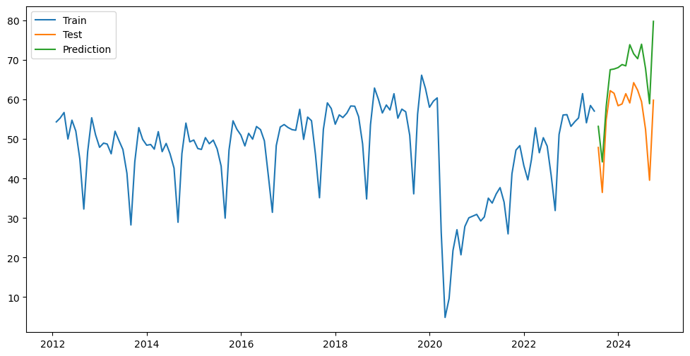

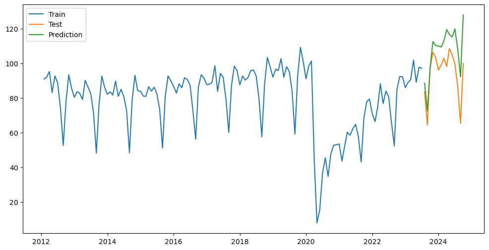

```python
def train_bsts_and_predict(df, test_size=15, sp=12):
    # Split the data into train and test sets
    train, test = df[:-test_size], df[-test_size:]

    # Define the model
    model = BSTS(seasonality=sp)

    # Fit the model to the training data
    model.fit(train,
            num_warmup = 200, # 2000
            num_samples = 200, # 2000
            num_chains= 2)

    # Generate predictions
    predictions = model.predict(len(test))

    # Ensure predictions have the same shape as test
    predictions = predictions[:len(test)].flatten()

    # Plot the results
    plt.figure(figsize=(12, 6))
    plt.plot(train.index, train, label='Train')
    plt.plot(test.index, test, label='Test')
    plt.plot(test.index, predictions[:len(test)], label='Prediction')
    plt.legend()
    plt.show()

# Generate predictions and plot for each dataframe
train_bsts_and_predict(df_autobus_month)
train_bsts_and_predict(df_metro_month)
train_bsts_and_predict(df_combined_month)
```

### Series trimestrales

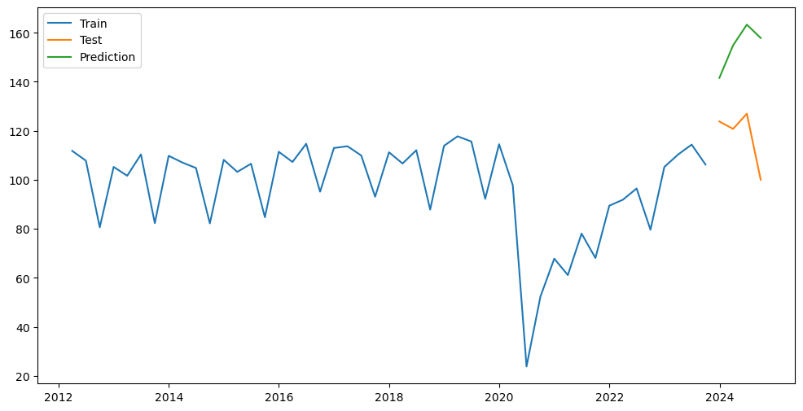

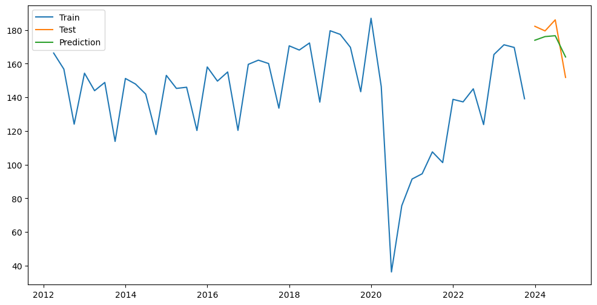

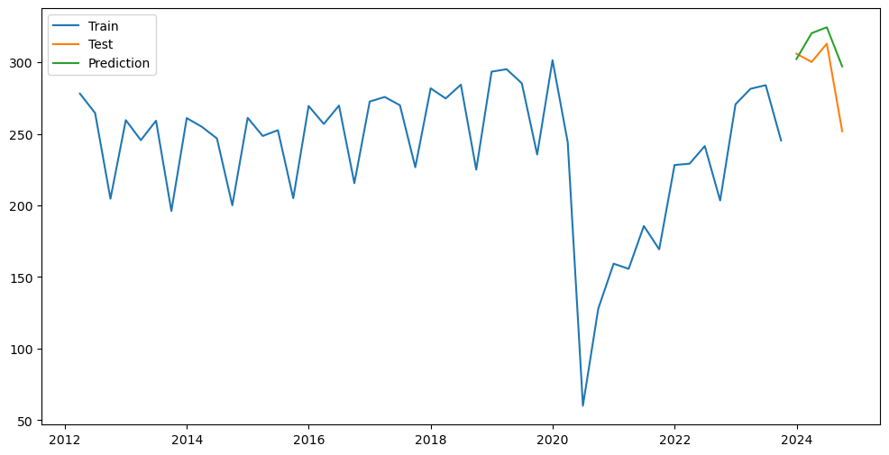

```python
train_bsts_and_predict(df_autobus_trim, test_size=4, sp=4)
train_bsts_and_predict(df_metro_trim, test_size=4, sp=4)
train_bsts_and_predict(df_combined_trim, test_size=4, sp=4)
```

## Conclusión BSTS

El coste computacional ha sido considerablemente alto debido al tiempo requerido para entrenarlos. Este tradeoff entre la alta capacidad de cómputo y la precisión de las predicciones es una desventaja significativa, ya que la complejidad del modelo y la estimación bayesiana de los parámetros no siempre resultan en mejoras sustanciales en la exactitud de las predicciones.